# 03 — Tipos de Float: Comprimindo Embeddings sem Perder Qualidade

## O problema de escala

Você já aprendeu que cada embedding é uma lista de números. Mas como esses números são armazenados na memória?

Cada número pode usar diferentes quantidades de bytes dependendo da **precisão**:

| Tipo | Bits | Bytes | Valores possíveis | Exemplo |
| --- | --- | --- | --- | --- |
| `float64` | 64 | 8 | 1.8 × 10^308 | 0.08312847362... |
| `float32` | 32 | 4 | 3.4 × 10^38 | 0.083128... |
| `float16` | 16 | 2 | 65.504 | 0.0831... |
| `int8` | 8 | 1 | -128 a 127 | 11 (≈ 0.083) |
| `binary` | 1 | 0.125 | 0 ou 1 | 0 |

**Por que isso importa?** Um índice vetorial de 1 milhão de documentos a 768 dimensões:

- `float32`: 3.07 GB (padrão, sem compressão)
- `float16`: 1.53 GB (metade)
- `int8`: 0.77 GB (1/4)
- `binary`: 0.10 GB (1/30)

Em produção, isso é a diferença entre caber numa instância de $200/mês ou precisar de $2.000/mês.

**A pergunta central deste notebook:** quanto de precisão você pode abrir mão antes que a qualidade de busca caia de forma inaceitável?

```python
import numpy as np
import pandas as pd
import matplotlib.pyplot as plt
import struct
import sys
sys.path.insert(0, '..')

from sentence_transformers import SentenceTransformer
from src.embeddings.quantization import (
    quantize_vectors, dequantize_vectors,
    memory_comparison_table, cosine_similarity_preservation
)

print('Modulos carregados!')
```

```
Modulos carregados!
```

## 3.1 Como cada tipo representa números

```python
valor = 0.123456789

f32 = np.float32(valor)
f16 = np.float16(valor)
i8_approx = np.int8(np.clip(round(valor * 127), -128, 127))

print(f'Valor original: {valor}')
print(f'float32: {f32}  (erro: {abs(float(f32) - valor):.2e})  [4 bytes]')
print(f'float16: {f16}  (erro: {abs(float(f16) - valor):.2e})  [2 bytes]')
print(f'int8:    {i8_approx} -> deq: {float(i8_approx)/127:.6f}  (erro: {abs(float(i8_approx)/127 - valor):.2e})  [1 byte]')

bits = ''.join(f'{b:08b}' for b in struct.pack('>f', valor))
print(f'\nfloat32 em bits: {bits}')
print(f'  Sign: {bits[0]} | Exponent: {bits[1:9]} ({int(bits[1:9], 2) - 127}) | Mantissa: {bits[9:]}')
```

```
Valor original: 0.123456789
float32: 0.12345679104328156  (erro: 2.04e-09)  [4 bytes]
float16: 0.12347412109375  (erro: 1.73e-05)  [2 bytes]
int8:    16 -> deq: 0.125984  (erro: 2.53e-03)  [1 byte]

float32 em bits: 00111101111111001101011011101010
  Sign: 0 | Exponent: 01111011 (-4) | Mantissa: 11111001101011011101010
```

## 3.2 Cálculo real de memória com embeddings reais

```python
model = SentenceTransformer('all-mpnet-base-v2')  # 768d

docs = [
    'Embeddings sao representacoes vetoriais de texto.',
    'Redes neurais aprendem padroes complexos nos dados.',
    'O Qdrant e um banco de dados vetorial open-source.',
    'RAG combina retrieval com geracao de linguagem.',
    'Quantizacao reduz memoria com minima perda de qualidade.',
] * 200  # 1000 documentos

embeddings = model.encode(docs, normalize_embeddings=True, show_progress_bar=True)
print(f'\nEmbeddings: {embeddings.shape} | dtype: {embeddings.dtype}')
```

```
Embeddings: (1000, 768) | dtype: float32
```

```python
table = memory_comparison_table(embeddings)

rows = []
bytes_per = {'float32': 4, 'float16': 2, 'int8': 1, 'binary': 0.125}
for dtype, stats in table.items():
    rows.append({
        'Tipo': dtype,
        'Bytes/elemento': bytes_per[dtype],
        '1K docs (768d) MB': f"{stats['mb']:.2f}",
        'Projecao 1M docs GB': f"{stats['gb'] * 1000:.2f}",
        'Reducao vs float32': 'baseline' if dtype == 'float32' else f"{stats['reduction_pct']:.0f}%",
        'Fator': '1x' if dtype == 'float32' else f"{stats['reduction_ratio']:.0f}x",
    })

df = pd.DataFrame(rows)
print('Uso de memoria para 1000 documentos a 768 dimensoes:\n')
print(df.to_string(index=False))
```

```
Uso de memoria para 1000 documentos a 768 dimensoes:

   Tipo  Bytes/elemento 1K docs (768d) MB Projecao 1M docs GB Reducao vs float32 Fator
float32           4.000              2.93                2.86           baseline    1x
float16           2.000              1.46                1.43                50%    2x
   int8           1.000              0.73                0.72                75%    4x
 binary           0.125              0.09                0.09                97%   32x
```

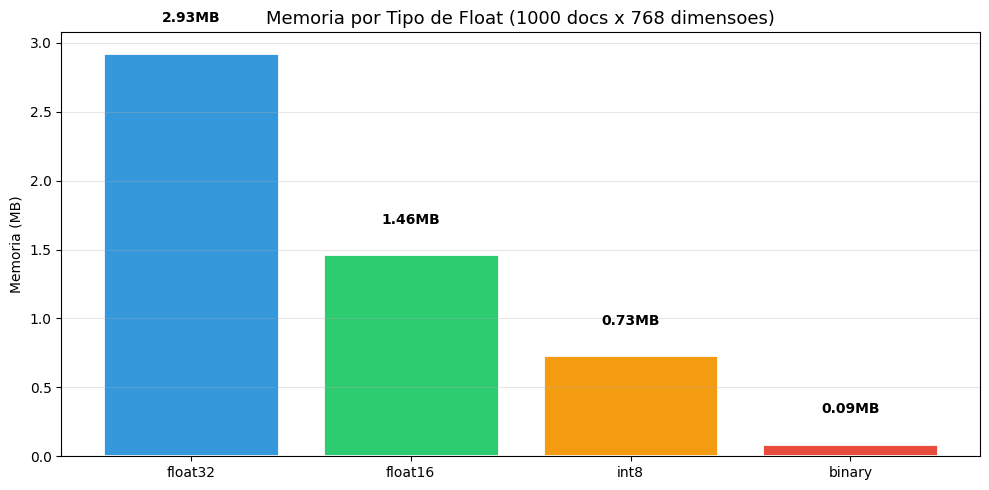

```python
# Visualizacao
tipos = list(table.keys())
memorias_mb = [table[t]['mb'] for t in tipos]
cores = ['#3498db', '#2ecc71', '#f39c12', '#e74c3c']

fig, ax = plt.subplots(figsize=(10, 5))
bars = ax.bar(tipos, memorias_mb, color=cores, edgecolor='white', linewidth=2)
for bar, mem in zip(bars, memorias_mb):
    ax.text(bar.get_x() + bar.get_width()/2, bar.get_height() + 0.2,
            f'{mem:.2f}MB', ha='center', va='bottom', fontweight='bold')

ax.set_title('Memoria por Tipo de Float (1000 docs x 768 dimensoes)', fontsize=13)
ax.set_ylabel('Memoria (MB)')
ax.grid(axis='y', alpha=0.3)
plt.tight_layout()
plt.show()
```

## 3.3 A Grande Questão: Quanto a Qualidade Cai?

Memória mais barata é ótimo — mas se os resultados de busca piorarem, não vale a pena.

- **Recall = 1.0**: quantização perfeita, zero perda de qualidade
- **Recall = 0.95**: 5% dos resultados são diferentes — aceitável para produção
- **Recall = 0.70**: 30% de perda — geralmente inaceitável

A hipótese é que `float16` perde pouco (arredondamento mínimo), `int8` perde um pouco mais mas é recuperável, e `binary` pode perder bastante para textos com nuances sutis.

```python
print('Medindo preservacao de similaridade cosine...\n')

quality_results = []
for dtype in ['float32', 'float16', 'int8', 'binary']:
    result = cosine_similarity_preservation(embeddings, dtype, sample_size=500)
    quality_results.append(result)
    print(f"{dtype:8s}: erro medio={result['mean_abs_error']:.5f} | "
          f"preservacao={result['preservation_pct']:.2f}% | "
          f"correlacao={result['correlation']:.5f}")

print('\nInterpretacao:')
print('  float16: quase identico ao float32 (erro ~0.001)')
print('  int8: pequena degradacao (~1-3%), otimo para producao')
print('  binary: degradacao significativa — so para busca aproximada em larga escala')
```

```
Medindo preservacao de similaridade cosine...

float32 : erro medio=0.00000 | preservacao=100.00% | correlacao=1.00000
```

[output not shown]

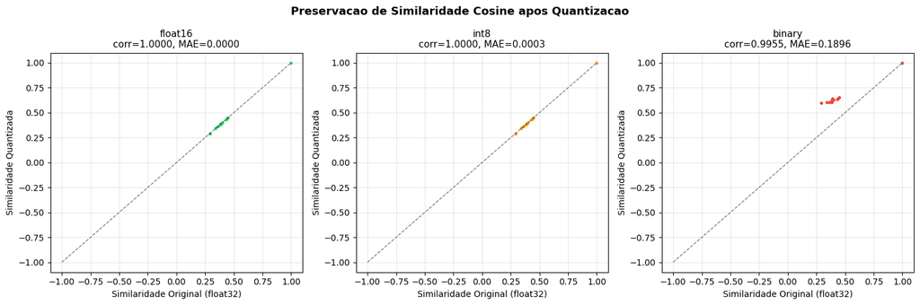

```python
# Scatter: similaridade original vs quantizada
fig, axes = plt.subplots(1, 3, figsize=(15, 5))

for i, (dtype, color) in enumerate([('float16', '#2ecc71'), ('int8', '#f39c12'), ('binary', '#e74c3c')]):
    n_sample = 200
    idx = np.random.choice(len(embeddings), n_sample, replace=False)
    sample = embeddings[idx]

    orig_norm = sample / np.linalg.norm(sample, axis=1, keepdims=True)
    orig_sims = (orig_norm @ orig_norm.T).flatten()

    quant = quantize_vectors(sample, dtype)
    dequant = dequantize_vectors(quant, dtype)
    q_norm = dequant / (np.linalg.norm(dequant, axis=1, keepdims=True) + 1e-9)
    q_sims = (q_norm @ q_norm.T).flatten()

    axes[i].scatter(orig_sims[::5], q_sims[::5], alpha=0.2, s=2, color=color)
    axes[i].plot([-1, 1], [-1, 1], 'k--', alpha=0.5, linewidth=1)

    corr = np.corrcoef(orig_sims, q_sims)[0, 1]
    mae = np.mean(np.abs(orig_sims - q_sims))

    axes[i].set_title(f'{dtype}\ncorr={corr:.4f}, MAE={mae:.4f}', fontsize=11)
    axes[i].set_xlabel('Similaridade Original (float32)')
    axes[i].set_ylabel('Similaridade Quantizada')
    axes[i].grid(True, alpha=0.3)

plt.suptitle('Preservacao de Similaridade Cosine apos Quantizacao', fontsize=13, fontweight='bold')
plt.tight_layout()
plt.show()
```

## 3.4 Quantizacao no Qdrant (Scalar Quantization)

```python
from qdrant_client import QdrantClient
from qdrant_client.models import (
    Distance, VectorParams, PointStruct,
    ScalarQuantization, ScalarQuantizationConfig, ScalarType
)

client = QdrantClient(host='localhost', port=6333, grpc_port=6334, prefer_grpc=True)

# Collection com int8 quantization nativa do Qdrant
if client.collection_exists('demo_quantization'):
    client.delete_collection('demo_quantization')
client.create_collection(
    collection_name='demo_quantization',
    vectors_config=VectorParams(size=768, distance=Distance.COSINE),
    quantization_config=ScalarQuantization(
        scalar=ScalarQuantizationConfig(
            type=ScalarType.INT8,
            quantile=0.99,
            always_ram=True,
        )
    )
)

points = [
    PointStruct(id=i, vector=embeddings[i].tolist(), payload={'text': docs[i]})
    for i in range(50)
]
client.upsert(collection_name='demo_quantization', points=points)

print('Collection criada com int8 quantizacao!')
print('Vantagens:')
print('  - Vetores armazenados como int8 (4x menos memoria)')
print('  - Busca ~2x mais rapida')
print('  - Recall tipico: 97-99%')
print('  - API identica — transparente para o usuario')
```

```
Collection criada com int8 quantizacao!
Vantagens:
  - Vetores armazenados como int8 (4x menos memoria)
  - Busca ~2x mais rapida
  - Recall tipico: 97-99%
  - API identica — transparente para o usuario
```

## Resumo: Guia de Decisao de Float Type

```
Precisa reduzir memoria?
├── Nao → float32 (qualidade maxima)
├── ~50% reducao → float16 (GPU disponivel? Excelente)
├── ~75% reducao → int8 / Scalar Quantization (RECOMENDADO para CPU)
└── >96% reducao → binary (so large-scale, aceitar 60-80% recall)
```

**Recomendacao para RAG de producao:**

> Use **int8 Scalar Quantization no Qdrant** — 75% menos memoria, 97%+ recall, 2x velocidade.

## Proximos passos

- 04 — Distance Metrics
- 02 — Qdrant Quantization

## Resumo e Decisão

| Cenário | Recomendação | Motivo |
| --- | --- | --- |
| Desenvolvimento local | `float32` | Simplicidade, sem surpresas |
| Produção geral | `int8` (Scalar) + rescore | 4x menos memória, ~99% recall |
| Grande escala (>10M docs) | Product Quantization | Compressão extrema necessária |
| Edge/mobile | `binary` | Memória mínima aceita recall ~70-80% |
| OpenAI/Anthropic API | `float32` ou `int8` | Custo de API domina, não memória |

**Próximos passos:**

- 04 — Métricas de Distância: qual distância usar com qual tipo de dado?
- 01 — Qdrant Intro: como configurar tudo isso no Qdrant